# Exercise 1

This exercise explores the off-line components available in **mirtCAT** that are useful for a) understanding the properties of CATs underling various circumstances, b) testing existing item banks given overt response patterns, and c) studying CATs with Monte Carlo simulations. Specifically, this exercise consists of building and studying a unidimensional CAT using known IRT parameters.

## Question 1

- Slope parameters (`a1`) are drawn from a log-normal distribution ($\ln\mu = .2$, $\ln\sigma = .2$)
- Intercepts (`d`) are drawn from a Gaussian distribution with ($\mu = 0$, $\sigma = 2$)
- Pseudo-guessing parameters (`g`) are drawn from a beta distribution with $\alpha = 20$ and $\beta = 80$ (note that R calls these ‘shapes’)

```r
library(mirtCAT)
set.seed(1)
pars <- data.frame(a1 = rlnorm(200, .2, .2),
                   d = rnorm(200, 0, 2),
                   g = rbeta(200, 20, 80))
mod <- generate.mirt_object(pars, itemtype = '3PL')
```

## Question 2

Inspect this newly constructed model with functions such as `coef()` and `plot()` to get a feel for how the CAT will behave. Note that modifying the `type` argument in combination with `which.items` will be helpful for presentation because of the larger number of items in the test.

```r
coef(mod, simplify=TRUE)
```

```
## $items
##             a1      d     g u
## Item.1   1.078  0.819 0.256 1
## Item.2   1.267  3.378 0.174 1
## Item.3   1.033  3.173 0.183 1
## Item.4   1.680 -0.662 0.182 1
## Item.5   1.305 -4.570 0.183 1
## Item.6   1.037  4.995 0.184 1
## Item.7   1.346  1.334 0.187 1
## Item.8   1.416  1.083 0.170 1
## Item.9   1.370 -0.027 0.183 1
## Item.10  1.149  1.020 0.232 1
## Item.11  1.653 -0.329 0.259 1
## Item.12  1.320  0.841 0.166 1
## Item.13  1.079 -0.800 0.178 1
## Item.14  0.784 -2.740 0.225 1
## Item.15  1.530  1.976 0.253 1
## Item.16  1.210  3.039 0.189 1
## Item.17  1.217 -0.617 0.281 1
## Item.18  1.475 -2.507 0.169 1
## Item.19  1.439  1.284 0.197 1
## Item.20  1.375 -0.089 0.124 1
## Item.21  1.468 -3.466 0.228 1
## Item.22  1.428  0.004 0.166 1
## Item.23  1.240 -1.261 0.172 1
## Item.24  0.820 -0.682 0.170 1
## Item.25  1.383 -2.313 0.112 1
## Item.26  1.208  3.606 0.224 1
## Item.27  1.184 -0.662 0.134 1
## Item.28  0.910 -3.211 0.199 1
## Item.29  1.110  0.394 0.229 1
## Item.30  1.328  0.526 0.191 1
## Item.31  1.603 -1.972 0.245 1
## Item.32  1.197 -5.778 0.199 1
## Item.33  1.320 -1.281 0.172 1
## Item.34  1.208  1.141 0.181 1
## Item.35  0.927 -0.119 0.199 1
## Item.36  1.124 -0.196 0.243 1
## Item.37  1.129  1.122 0.209 1
## Item.38  1.207 -2.373 0.141 1
```

[output cut: 155 more lines]

```
## Item.194 1.442  0.613 0.189 1
## Item.195 0.959 -0.220 0.189 1
## Item.196 0.990 -1.849 0.123 1
## Item.197 1.629  3.186 0.234 1
## Item.198 0.997  0.090 0.152 1
## Item.199 1.326 -1.430 0.235 1
## Item.200 1.132  1.730 0.189 1
##
## $means
## F1
##  0
##
## $cov
##    F1
## F1  1
```

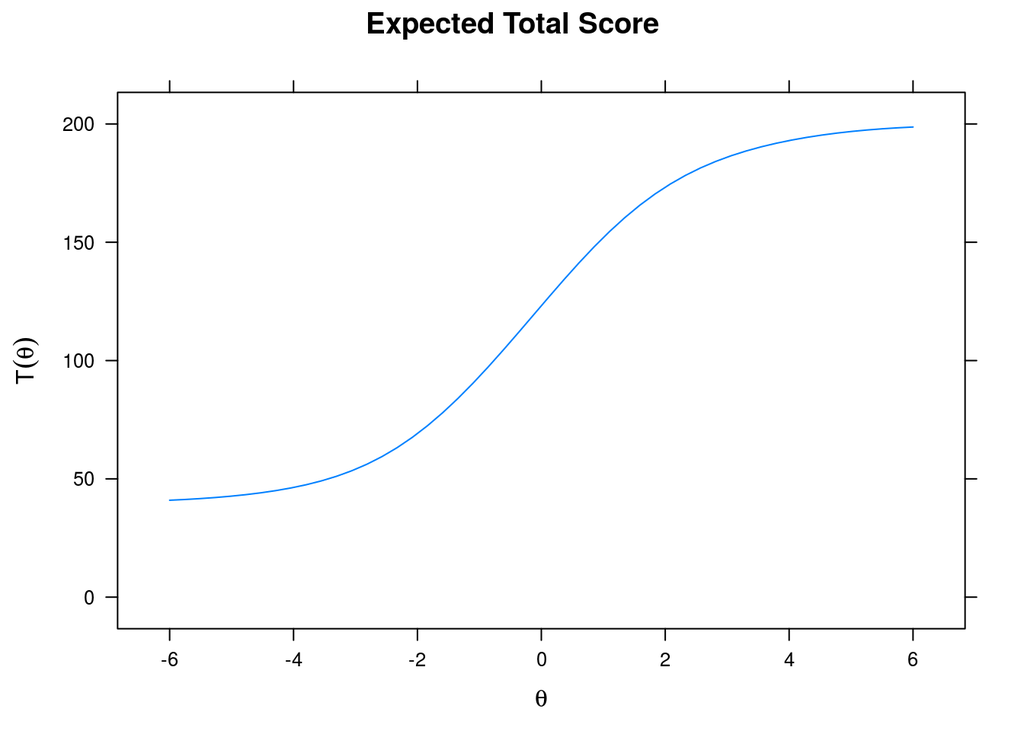

```r
plot(mod)
```

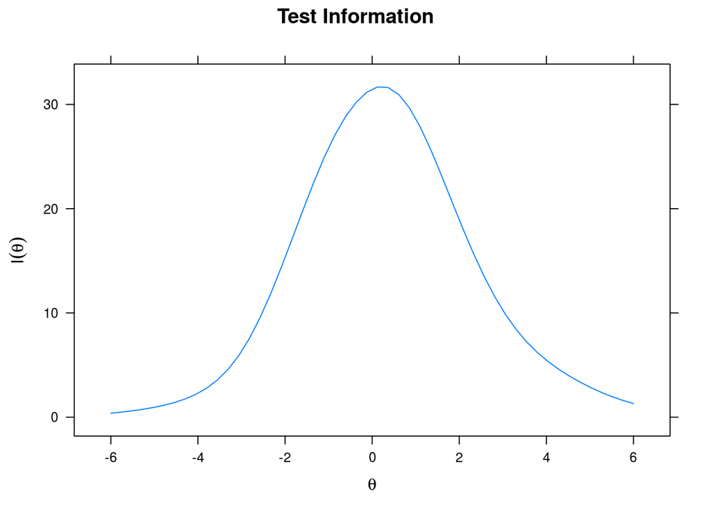

```r
plot(mod, type = 'info')
```

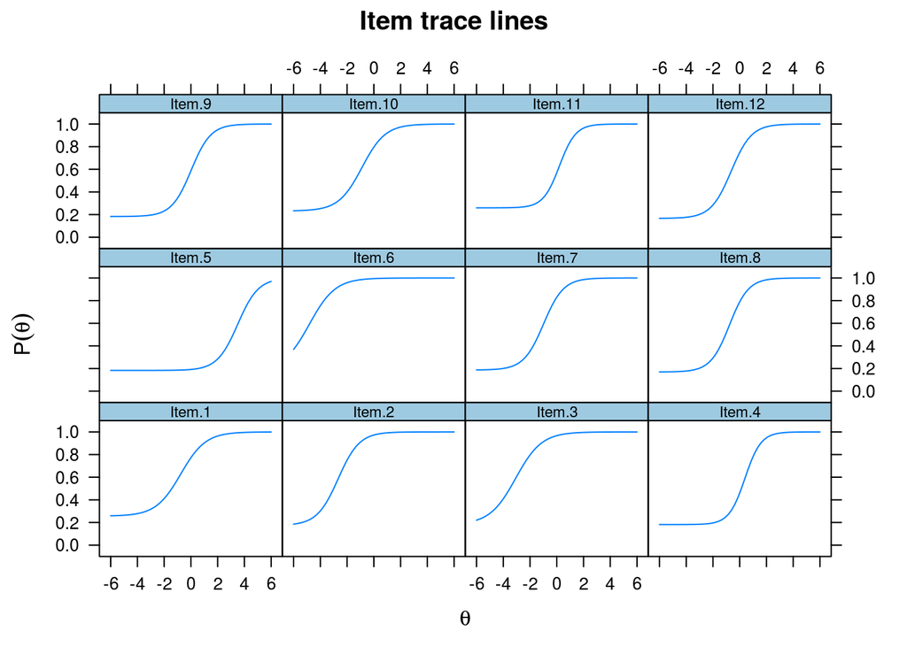

```r
plot(mod, type = 'trace', which.items=1:12)
```

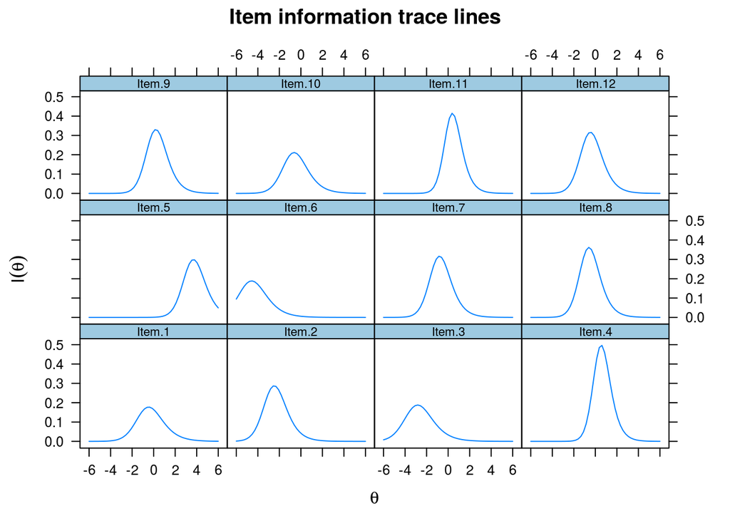

```r
plot(mod, type = 'infotrace', which.items=1:12)
```

## Question 3

Given the constructed model, generate a plausible response pattern for a participant with the ability $\theta = 0.5$ using the `generate_pattern()` function.

After generating this pattern, supply the vector of responses to `mirtCAT()` and administer the items sequentially while estimating $\hat{\theta}$ using a MAP estimator. However, modify the inputs such that *all* the items are answered (hint: modify the `min_items` or `min_SEM` argument). Summarize and plot the CAT session results.

```r
set.seed(1)
pat <- generate_pattern(mod, 0.5)
results <- mirtCAT(mo = mod, criteria = 'seq', method = 'MAP',
                   local_pattern = pat, design = list(min_items = 200))
(so <- summary(results))
```

```
## $final_estimates
##             Theta_1
## Estimates 0.5681494
## SEs       0.1769868
##
## $raw_responses
##   [1] "2" "2" "2" "2" "1" "2" "2" "2" "2" "1" "1" "2" "2" "1" "2" "2" "2"
##  [18] "2" "2" "2" "2" "1" "2" "1" "1" "2" "1" "1" "2" "2" "1" "1" "1" "2"
##  [35] "2" "2" "2" "1" "2" "2" "2" "2" "2" "1" "2" "1" "1" "2" "2" "2" "2"
##  [52] "2" "2" "1" "1" "2" "1" "2" "2" "1" "2" "1" "2" "2" "2" "2" "2" "2"
##  [69] "1" "2" "1" "2" "1" "2" "2" "2" "2" "2" "2" "2" "2" "2" "2" "1" "2"
##  [86] "1" "2" "2" "2" "2" "1" "1" "2" "2" "2" "2" "2" "2" "2" "2" "2" "1"
## [103] "2" "2" "2" "2" "1" "2" "2" "2" "2" "2" "1" "1" "1" "1" "2" "1" "1"
## [120] "2" "2" "2" "2" "1" "2" "2" "2" "1" "1" "2" "2" "1" "1" "2" "2" "2"
## [137] "2" "2" "2" "2" "2" "1" "2" "1" "1" "1" "2" "2" "2" "2" "2" "2" "2"
```

[output cut: 436 more lines]

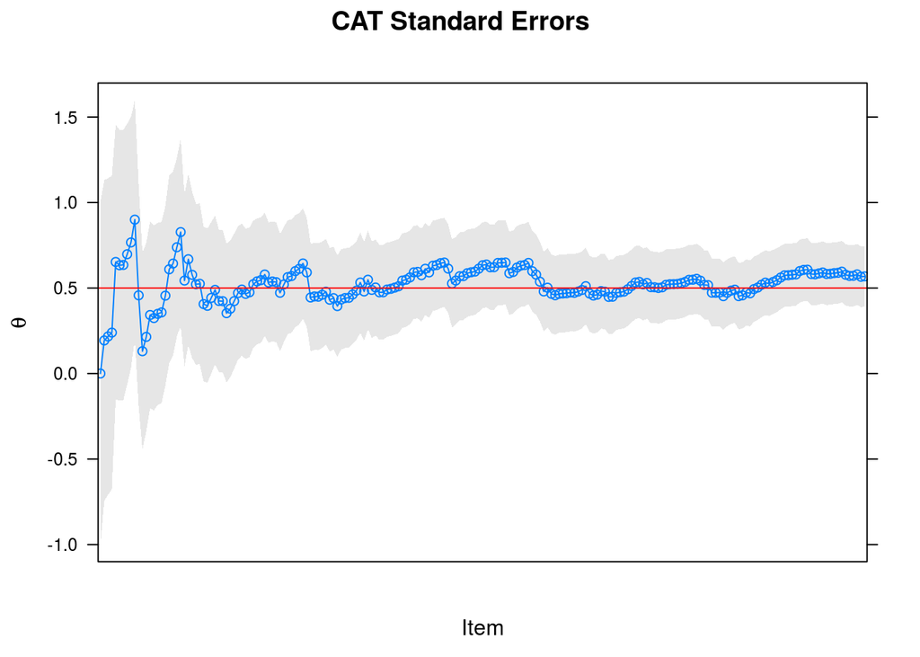

```r
plot(results, scales=list(x = list(at=NULL)))
```

## Question 4

```r
results2 <- mirtCAT(mo = mod, criteria = 'MI', method = 'MAP',
                   local_pattern = pat, design = list(max_items = 40,
                                                   min_SEM = .3))
(so2 <- summary(results2))
```

```
## $final_estimates
##             Theta_1
## Estimates 0.4200666
## SEs       0.2995440
##
## $raw_responses
##  [1] "2" "2" "2" "1" "2" "2" "2" "1" "1" "1" "2" "2" "2" "2" "2" "1" "1"
## [18] "2" "2" "1" "2" "2" "2" "2" "2" "1" "1" "1" "2" "2"
##
## $scored_responses
##  [1] 1 1 1 0 1 1 1 0 0 0 1 1 1 1 1 0 0 1 1 0 1 1 1 1 1 0 0 0 1 1
##
## $items_answered
##  [1]   1 171  70 113 178   4  87 163 160  11 110 179  20 164  48 133  22
## [18]  93  40  71 177  63   9 135  85 107  69  92  43 166
```

[output cut: 71 more lines]

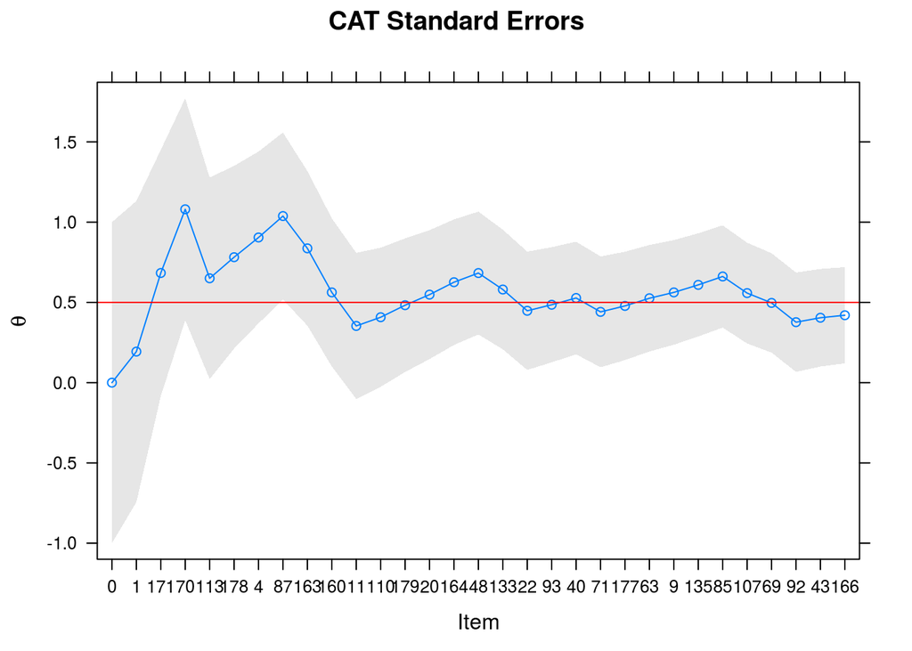

```r
plot(results2)
```

Compare the SEs to the SEs in the previous question where all the items where administered in sequence. What do you notice about the general behavior?

```r
nitems <- nrow(so2$thetas_SE_history)
data.frame(adaptive_MI = unname(so2$thetas_SE_history),
           sequential = so$thetas_SE_history[1:nitems, ])
```

```
##    adaptive_MI sequential
## 1    1.0000000  1.0000000
## 2    0.9382219  0.9382219
## 3    0.7672599  0.9254569
## 4    0.6913095  0.9158220
## 5    0.6275598  0.8013803
## 6    0.5688908  0.7917635
## 7    0.5352692  0.7909730
## 8    0.5205044  0.7623468
## 9    0.4815077  0.7337030
## 10   0.4613736  0.6987501
## 11   0.4551094  0.6476313
## 12   0.4332145  0.5737407
## 13   0.4160426  0.5503800
## 14   0.4013598  0.5446463
```

[output cut: 17 more lines]

## Question 5

Save your model object to your hard-drive using either `save()` or `saveRDS()`. We will use this object again in a later example.

```r
saveRDS(mod, 'myCATmodel.rds')
```